# **APC308 - Data Mining**

## Lab: Data Cleaning

At the end of this lab session, you will be able to:

- Use Pandas to perform various data cleaning tasks.
- Do visual and non-visual exploratory data analysis (EDA) in order to clean data.

# 1. Data Cleaning Basics

- You may remember the GIGO (Garbage In, Garbage Out) concept in programing. The quality of the input determines the quality of the output.
- Often times the real-world data is huge, messy and unclean. Doing data analytic or mining operations on dirty data could lead to an unreliable and incorrect result.
- A number of factors could contribute to an unclean data including data entry errors, poorly designed forms for data collection, duplicate data, inconsistent data formats, outdated data (data decay), etc.
- The data cleaning process attempts to enhance the quality of the data by filling missing values, getting rid of inconsistencies, smoothing out noise (a random error in a measured variable).
- Data cleaning can be seen as one form of `data preprocessing` along with other operations such as data integration, data reduction, data transformation, etc. You may recall our discussion on the KDD process shown in the figure below.
- In this lab session, we will focus on some common data cleaning operations that would help us to preprate our data for reliable mining.

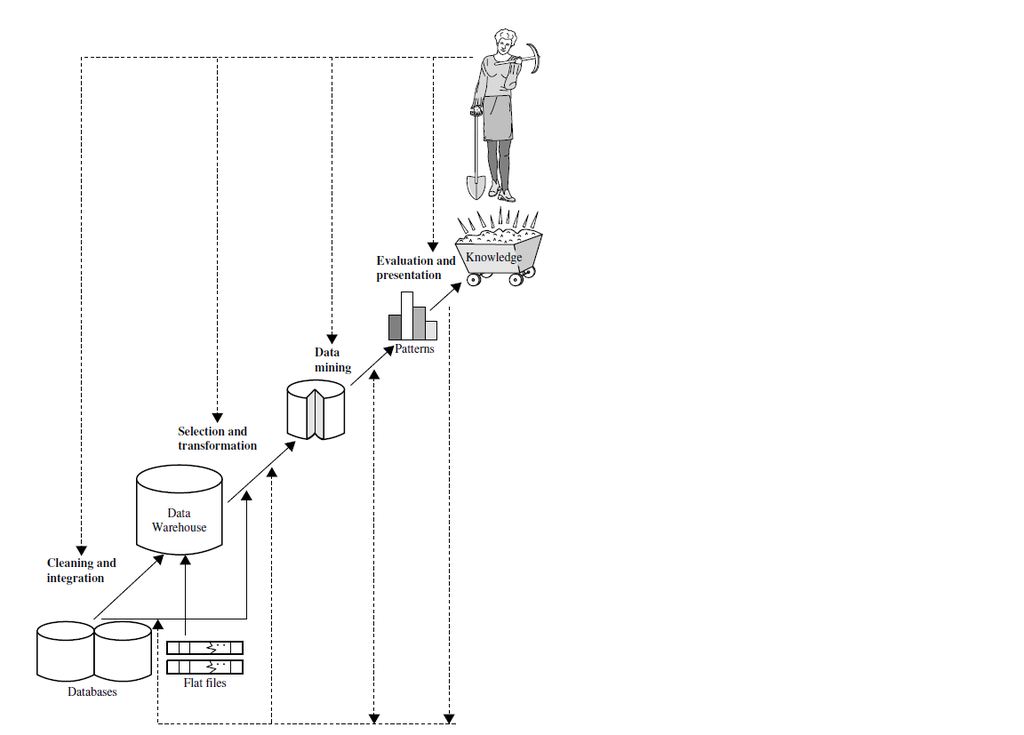

```python
from IPython.display import Image
Image("KDD.png", width=800, height=800)
```

### Activity!

- Find out about the following buzz words: data preprocessing, data wrangling (munging), feature engineering (extraction).

# 2. Getting Started with Data Cleaning

First off, import the required libraries.

```python
import pandas as pd
import matplotlib.pyplot as plt
import numpy as np
import seaborn as sns
import missingno as msno

import warnings                          # to silence warning if need be
warnings.filterwarnings('ignore')
```

Import the input dataset to work on.

```python
# The Applicants dataset shall be used

data = pd.read_csv('Applicants.csv')

data
```

Explore the dataset to better understand it.

```python
#data.info()

#data.describe()

data.columns
```

```python
data.head(50)                   # Notice anything strange?

#data.tail(20)
```

## 2.1 Finding Missing values

### isna(), notna()

```python
#data.isna()               # try notna() too

data.isna().sum()        # total number of missing values

#data['LoanAmount'].isna().sum()            # find missing values in a specific column
```

### isnull(), notnull()

```python
data.isnull()                  # try notnull()

#data.isnull().sum()

# Try to find number of missing values in a partcular column
```

### Unique values: unique()

```python
pd.unique(data['Gender'])         # unique values
```

### value_counts()

```python
data['Gender'].value_counts()     # number of values of different genders
```

## Visualization of Missing values

- There are useful libraries that help in the visual inspection of missing values. One such library is [missingno](https://pypi.org/project/missingno/).
- The library provides the following plot types:
1. **Matrix plot**: helps us to better visualize missing values.
1. **Bar plot**: count of values present in columns excluding missing values.
1. **Heatmap**: shows nullity correlation between columns of the dataset. The stronger the blue, the more the correlation. The correlation ranges from -1 to 1. -1 is negative correlation (if one value is present, the other is missing), 0 (no correlation), and 1 (positive correlation).
1. **Dendrogram**: shows the hierarchical relationship between attributes by grouping together (clustering) columns that have more nullity relation. Attributes that have stronger connection in missing values between them will be kept in the same cluster.
- The library can be installed using `pip` or `conda`. Go ahead and do so if not installed already.

### Matrix plot

```python
msno.matrix(data)


#msno.matrix(data, figsize=(10,4), fontsize=12, color=(0.2, 0.4, 0.5) )
```

### Bar Chart

```python
msno.bar(data)

#msno.bar(data, color="orange", sort="ascending")
```

### Heatmap

```python
msno.heatmap(data)
```

### Dendrogram

```python
msno.dendrogram(data)

#msno.dendrogram(data, orientation="top", fontsize=16)
```

## 2.2 Dealing with Missing Values

There are a number of approaches to deal with missing values. Each has its pros and cons. We shall see selected methods in this lab session:

1. Dropping the attribute/instance with missing values. This should be used carefully (e.g. when a column has many missing values).
1. Filling missing values with a global constant such as 0, 'unknown', 'missing', etc.
1. Imputing (substituting) missing values with compensation values such as mean and median.
1. Filling missing values with the most probably value using techneiques such as regression. More on regression later in this module.

### 1. dropping columns/rows

### dropna()

```python
# let us use a simple dataset that has some missing values
df = pd.read_csv('students.csv')

df
```

```python
# check for missing values
df.isnull().sum()
```

```python
df2 = df.dropna(axis=1)               # axis=1 for column.

df2
```

```python
df3 = df.dropna(axis=0)

df3
```

### 2. Filling with a Global Constant

### fillna()

```python
mydf = df.fillna('unknown')

#mydf = df['genre'].fillna('unknown')           # specific columns

mydf
```

### 3. Imputation using mean, median or mode

```python
df

imputeValue = df['age'].mean()

#df['age'].fillna(imputeValue, inplace=True)  # in-place modification of the original dataframe

#df
```

## 2.3 Dealing with Duplicates and Wrong Formats

### Finding duplicate rows: duplicated()

```python
df.duplicated()
```

```python
df.duplicated().sum()
```

### Removing duplicates: drop_duplicates()

```python
df_noDup = df.drop_duplicates()

df_noDup
```

### Wrong Formats

```python
df.dtypes
```

Notice the data type of the `age` feature. We can change attributes from one format/type to another. Pandas provides methods such as [astype()](https://pandas.pydata.org/docs/reference/api/pandas.DataFrame.astype.html) and [apply()](https://pandas.pydata.org/docs/reference/api/pandas.DataFrame.apply.html) for such conversions.

```python
# Let's try the following

df['age'] = df['age'].astype(int)                   # Try to fix the error

#df.dtypes
```

```python
# Alternative approach

#df = df.astype({"age":'int'})

#df.dtypes
```

#### Activity! Now, try doing the same using the apply() method.